# Machine Learning, Linear Regression

# Baclground and Introduction

The objective is to predict hosuing prices using linear regression , kc hosuing data which were sold in KC county washington. We have two things here, one is dependent variable and one is outcome variable Linear regression estimates are used to explain the relationship between one dependent variable and one or more independent variables.

Linear Regression Analysis consists of more than just fitting a linear line through a cloud of data points.  
It consists of 3 stages –

1. analyzing the correlation of the data,
2. estimating the model, i.e., fitting the line,
3. evaluating the validity and usefulness of the model.

Steps to implement the linear regression model

1. First import the file, perform data preprocessing just see the data and if we find any outlier or null and Find if there are any correlations between the data.
2. Now we create a base model for our linear regression. Create linearmodel and define the required methods. We import the models, use fit method to train the data for this purposes we used sklearn https://scikit-learn.org/stable/
3. Validation of model, to validate that created model is vaild, we create plots to see the predicted line and the points where the required value should be. its kind of we see how far the predicated values are from actual real values

# A few lines about Data

Let's describe the data we will be using for our linear regression purpose. This dataset consist of values of sales price of houses in King County, Washington. It includes homes sold between May 2014 and May 2015. Features (in simple words values such as, house price, size, no of rooms etc)

The dataset cantains 20 house features, and we have 21613 observations.

The description for the 20 features is given below:

1. id :- It is the unique numeric number assigned to each house being sold.
2. date :- It is the date on which the house was sold out.
3. price:- It is the price of house which we have to predict so this is our target variable.
4. bedrooms :- It determines number of bedrooms in a house.
5. bathrooms :- It determines number of bathrooms in a bedroom of a house.
6. sqft_living :- It is the measurement variable which determines the measurement of house in square foot.
7. sqft_lot : It is also the measurement variable which determines square foot of the lot.
8. floors: It determines total floors means levels of house.
9. waterfront : This feature determines whether a house has a view to waterfront 0 means no 1 means yes.
10. view : This feature determines whether a house has been viewed or not 0 means no 1 means yes.
11. condition : It determines the overall condition of a house on a scale of 1 to 5.
12. grade : It determines the overall grade given to the housing unit, based on King County grading system on a scale of 1 to 11
13. sqft_above : It determines square foot of house apart from basement.
14. sqft_basement : It determines square footage of the basement of the house.
15. yr_built : It detrmines the date of building of the house.
16. yr_renovated : It detrmines year of renovation of house.
17. zipcode : It determines the zipcode of the location of the house.
18. lat : It determines the latitude of the location of the house.
19. long : It determines the longitude of the location of the house.
20. sqft_living15 : Living room area in 2015
21. sqft_lot15 : lotSize area in 2015

First, we **import** the required libraries like pandas, numpy, seaborn, matplotlib.

Finally, that we plot graphs for better understanding or better analysis.

```python
import pandas as pds   # data importation and manipulations
import numpy as npy    # for array manipulations
```

```python
#read the csv file into dataframe
data=pd.read_csv('https://raw.githubusercontent.com/dbendet/coursera_machine_learning/master/kc_house_data.csv',error_bad_lines=False) #importing the data,we placed data file in same project folder.
```

# Preprocessing of Data

```python
print(type(data))  # looking the data what it is
print(len(data))   # checking the length, looks like we got 21K+ data samples
```

```
<class 'pandas.core.frame.DataFrame'>
21613
```

```python
data.tail() # lets check final records
```

|  | id | date | price | bedrooms | bathrooms | sqft_living | sqft_lot | floors | waterfront | view | ... | grade | sqft_above | sqft_basement | yr_built | yr_renovated | zipcode | lat | long | sqft_living15 | sqft_lot15 |
| --- | --- | --- | --- | --- | --- | --- | --- | --- | --- | --- | --- | --- | --- | --- | --- | --- | --- | --- | --- | --- | --- |
| 21608 | 263000018 | 20140521T000000 | 360000.0 | 3 | 2.50 | 1530 | 1131 | 3.0 | 0 | 0 | ... | 8 | 1530 | 0 | 2009 | 0 | 98103 | 47.6993 | -122.346 | 1530 | 1509 |
| 21609 | 6600060120 | 20150223T000000 | 400000.0 | 4 | 2.50 | 2310 | 5813 | 2.0 | 0 | 0 | ... | 8 | 2310 | 0 | 2014 | 0 | 98146 | 47.5107 | -122.362 | 1830 | 7200 |
| 21610 | 1523300141 | 20140623T000000 | 402101.0 | 2 | 0.75 | 1020 | 1350 | 2.0 | 0 | 0 | ... | 7 | 1020 | 0 | 2009 | 0 | 98144 | 47.5944 | -122.299 | 1020 | 2007 |
| 21611 | 291310100 | 20150116T000000 | 400000.0 | 3 | 2.50 | 1600 | 2388 | 2.0 | 0 | 0 | ... | 8 | 1600 | 0 | 2004 | 0 | 98027 | 47.5345 | -122.069 | 1410 | 1287 |
| 21612 | 1523300157 | 20141015T000000 | 325000.0 | 2 | 0.75 | 1020 | 1076 | 2.0 | 0 | 0 | ... | 7 | 1020 | 0 | 2008 | 0 | 98144 | 47.5941 | -122.299 | 1020 | 1357 |

5 rows × 21 columns

```python
#finding the shape of dataframe its 21613 rows and 21 columns data
data.shape
```

```
(21613, 21)
```

```python
# looking at data to see what kind of columns which we also call features and what is data type
data.info()
```

```
<class 'pandas.core.frame.DataFrame'>
RangeIndex: 21613 entries, 0 to 21612
Data columns (total 21 columns):
id               21613 non-null int64
date             21613 non-null object
price            21613 non-null float64
bedrooms         21613 non-null int64
bathrooms        21613 non-null float64
sqft_living      21613 non-null int64
sqft_lot         21613 non-null int64
floors           21613 non-null float64
waterfront       21613 non-null int64
view             21613 non-null int64
condition        21613 non-null int64
grade            21613 non-null int64
sqft_above       21613 non-null int64
sqft_basement    21613 non-null int64
yr_built         21613 non-null int64
yr_renovated     21613 non-null int64
zipcode          21613 non-null int64
lat              21613 non-null float64
long             21613 non-null float64
sqft_living15    21613 non-null int64
sqft_lot15       21613 non-null int64
dtypes: float64(5), int64(15), object(1)
memory usage: 3.5+ MB
```

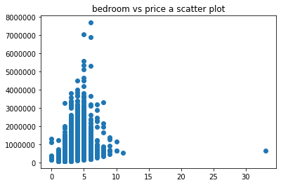

```python
import matplotlib.pyplot as plt # for plotting

#checking the data types
plt.scatter(data.bedrooms, data.price)
plt.title("bedroom vs price a scatter plot")
```

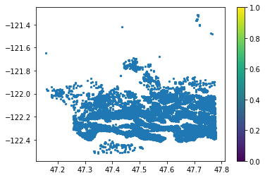

```python
# checking for the density and plotting mapp
import matplotlib.pyplot as plt
plt.scatter(data.lat, data.long,5)
plt.colorbar()
plt.show()
```

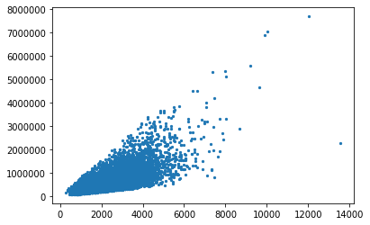

```python
plt.scatter(data.sqft_living, data.price,5)
plt.show()
```

# Plots for understanding or Analysis

[figure not shown]

```
<function seaborn.utils.despine(fig=None, ax=None, top=True, right=True, left=False, bottom=False, offset=None, trim=False)>
```

```python
import seaborn as sns # for data visualization

plt.scatter(data.bathrooms, data.sqft_living)  # using scatter plot to see co relation b/w bedroom & price
plt.title("bathroom and living squarefoot")
plt.xlabel("bathrooms")
plt.ylabel("Price")
plt.show()
sns.despine
```

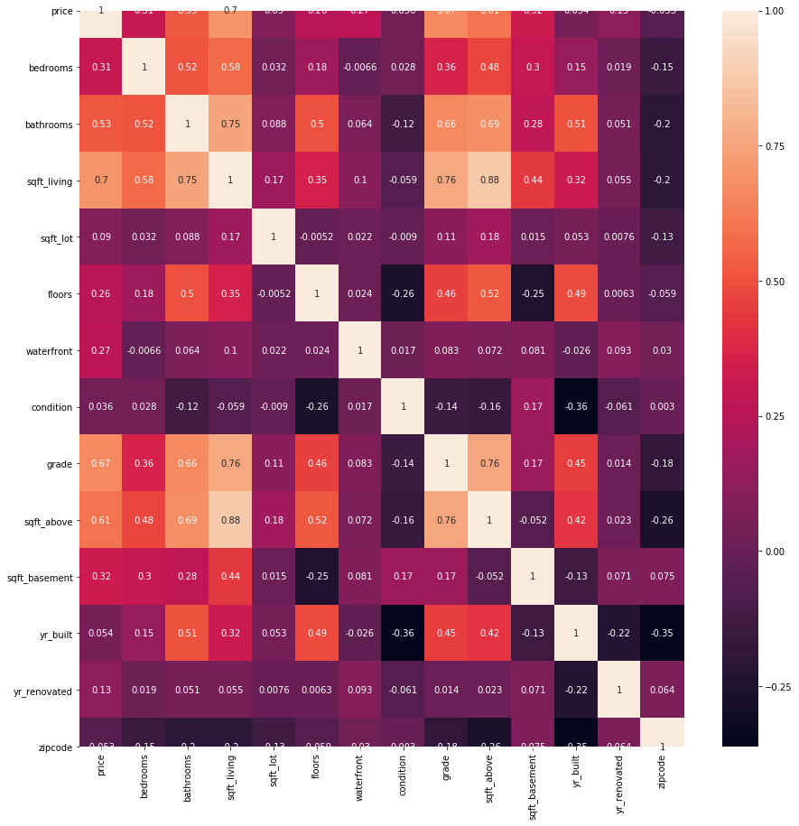

```python
#heatmap for all the required features for correlation
datacor=data[['price', 'bedrooms', 'bathrooms', 'sqft_living',
    'sqft_lot', 'floors', 'waterfront', 'condition', 'grade',
    'sqft_above', 'sqft_basement', 'yr_built', 'yr_renovated', 'zipcode']]
fig, ax = plt.subplots(figsize=(15,15))
sns.heatmap(datacor.corr(),annot=True,ax=ax)
```

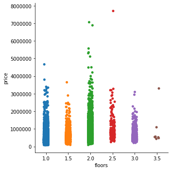

```python
#catplot for condition and price
df =  data
sns.catplot(x='floors',y='price',data=df)
```

# Preliminary Observation

(1) The frequency of no of bedrooms=3,4 is higher than any other bedrooms. The price of these are mostly similar, but some have giher price than usual because of the other features like bathrooms, location, etc.

(4) Most of the houses have sqft living in between 500 to 6000 irrespective of no of bedrooms. The higer the living space, the higher is the cost.

# Fitting the Linear Regression Model

```python
from sklearn.linear_model import LinearRegression
from sklearn.model_selection import train_test_split

Regression = LinearRegression()   # linear regression class

labels =  data['price']    # settign labels

if 'id' in data:
    del data['id']


train_data = data.drop(['price','date'], axis = 1) # as axis = 0 is for rows and axis=1 for columns so we dropping column

# splitting the dataset
train_data, test_data, train_data_labels, test_data_labels = train_test_split(train_data, labels, test_size=0.2, random_state=5)  # test size 20%

# startting to fit the line
Regression.fit(train_data, train_data_labels)
# checking accuracy score after training
score = Regression.score(test_data, test_data_labels)
print('Accuracy of system: ', score*100 )
```

```
Accuracy of system:  69.99336820782688
```

```python
#getting a prediction for the following test value such as date, bedrooms, bathrooms, sqft living,
#sqfit lot, floors, waterfront etc and see how much it cast. change the value and see the price
#rediction for given house
pred_arr =np.array([[3],[2],[2040],[4125],[1.5],[0],[0],[4],[8],[1540],[500],[1917],[0],[98107],[47.6608],[-122.359],[1620],[4400]])

# #pred_arr
pred_arr = pred_arr.reshape(1,-1) # custom prediction test by us prediction, reshaping to chane the dimensions


pred = Regression.predict(pred_arr)
print("prediction, Given Configuration house will cost: $",int(pred[0]))
```

```
prediction, Given Configuration house will cost: $ 775131
```

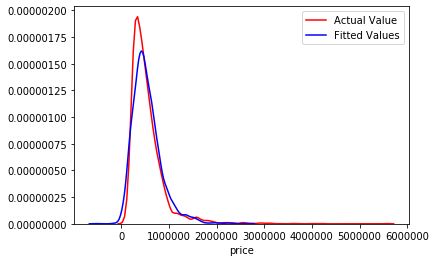

```python
# plotting the actual and predicted values

predictions = Regression.predict(test_data) # Total predictions. testing on our part of part

ax1 = sns.distplot(test_data_labels, hist=False, color="r", label="Actual Value")
sns.distplot(predictions, hist=False, color="b", label="Fitted Values" , ax=ax1)
```

# Conclusion

Aim of this project was to demonstrate the kc housing prices. We performed data preprocessing and Exploratory data analysis on the dataset, kc hosuing data which is publically available dataset, to obtain the correlations between the features and find which features are useful for predicting linear regression model, We ploted graphs of prediction and actual for the line and see if it fits correctly for the predicted or not. Our training and testing shows we have achieved 70% accuracy